## Introduction

3C data measuring the interaction frequency between two genomic coordinates can be represented graphically in different ways. Often, simple barplots are used and comics are drawn to indicate the genomic position of anchors and restriction fragments of interest. However, this can be tedious and errorprone.  
3C data can also be represented as arcs spanning from the anchor (aka viewpoint) to the regions of interest (aka restriction fragments) rendering a precise illustration of the genomic context. In these plots, the interaction frequency correlates with the hight of the arc. A published example of such a plot can be found [here](https://www.ncbi.nlm.nih.gov/pubmed/26308897).  
To my knowledge, there is no R package that conveniently generates this kind of plot. Below is my ggplot solution to generate ‘3C arc plots’. Feel free to email me with any questions, improvements or comments.

### Load packages and set ggplot themes

```r
# load required packages
library(tidyverse)
# these are general theme settings I commonly use for publication-grade plots
theme_linedraw_noframe <- theme_linedraw()+
  theme(panel.grid = element_blank(),
        panel.border = element_blank(),
        axis.line = element_line(),
        legend.justification = c(1, 1),
        legend.position = c(1, 1)) # move the legend into the plot
```

### Load data

The dummy datasets is an example of an 3C experiment you would do in the lab:  
From one specific anchor, the interaction frequencies to 4 different fragments of interest are tested in two different conditions (control and knock-down). For each condition we have 3 replicates. If you would like to follow along, download the dummy data [here](https://jchellmuth.github.io/downloads/2020-01-03-3C-dummy-data.txt).

```r
# read 3C data
df <- read_tsv("2020-01-03-3C-dummy-data.txt",)
```

### Reformat data

The following steps first convert the data to long format (generally required for plotting with ggplot) using dplyr’s `gather`. We then generate the midpoint between anchor and fragment of interest - this is essentially the coordinate where the interaction frequency data will be plotted.  
We then summarize the data from all three replicates in each group for each assay (i.e. anchor - fragment pair) using dplyr’s `group_by` and `summarize`.  
To plot a nice arc from anchor, over midpoint to fragment of interest coordinates, we need to ‘add back’ the anchor and fragment rows to the long format (this is done by another `gather` command) and set the interaction frequency at these points to 0 (once you look at the final plot, this will make sense).  
Because ggplot’s `geom_line` needs groups to know which points should be connected, a new column combining condition and assay.name is generated.

```r
# gather to convert from wide to long format
dfg <- df %>%
  gather(-assay.name,-anchor.coord,-fragment.coord,key = "sample",value = "frequency")
# extract condition from sample name
dfg$condition <- gsub("\\..*","",dfg$sample)
# calculate midpoint between each anchor and bait coordinate (the interaction frequency is going to be plotted over this coordinate)
dfg$mid.coord=(dfg$fragment.coord+dfg$anchor.coord)/2
# summarize data
dfs <- dfg %>%
  group_by(condition,anchor.coord,fragment.coord,mid.coord,assay.name) %>%
  summarise(mean.frequency=mean(frequency),sd.frequency=sd(frequency))
# 'add back' anchor and fragment rows using gather and rename key / points
dfsg <- dfs %>%
  gather(-condition,-mean.frequency,-sd.frequency,-assay.name,key = point,value = coord) %>%
  mutate(point=gsub(".coord","",point))
# set anchor and probe frequency to 0:
dfsg$mean.frequency[dfsg$point %in% c("anchor","fragment")] <- 0
# add group column (for ggplot's geom_line)
dfsg$group <- paste0(dfsg$condition,dfsg$assay.name)
```

## Plots

### 3C arc plot

The basic principle here is to use ggplots `stat_smooth` to plot a second degree polynomial regression line from the anchor over the midpoint to the fragment of interest genomic coordinates. Note that the interaction frequency at the anchor and the fragment are set to 0. The actual interaction frequency data is plotted to the midpoint.

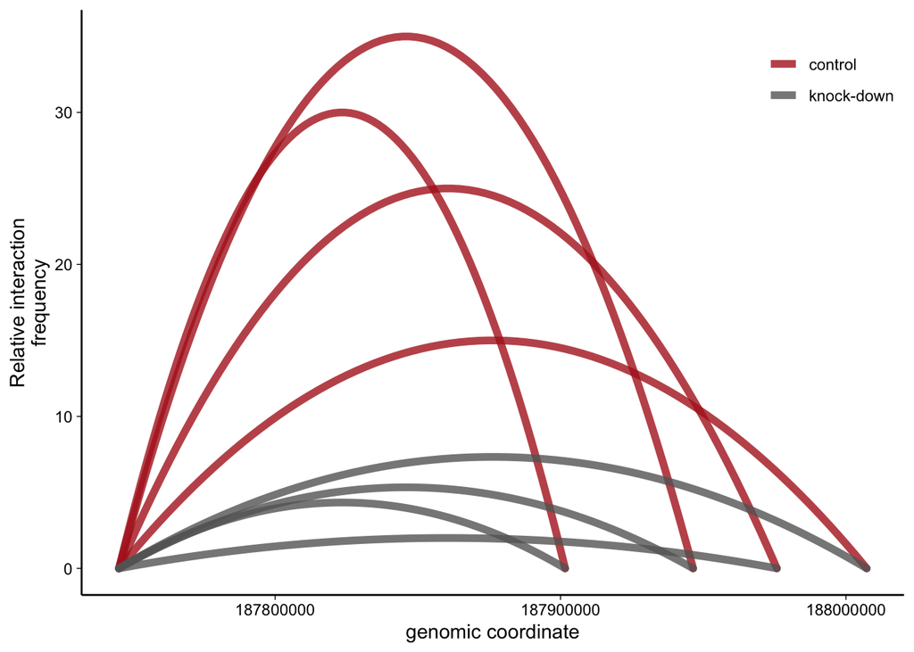

```r
p <- ggplot(dfsg,aes(x=coord,y=mean.frequency,color=condition,group=group))+
  geom_line(stat="smooth",method = "lm",formula = y ~ poly(x, 2),
            se = FALSE,lineend="round",size=2,alpha=0.8)+
  scale_color_manual(values = c("firebrick","grey40"))+ # pick colors manually
  labs(y="Relative interaction\nfrequency",x="genomic coordinate",color="")+ # rename axis labels
  theme_linedraw_noframe # these are the theme settings defined above
p
```

### 3C arc plot with errorbars

If you like, you could add errorbars to this plot - depending on how many fragments you are looking at, this could get messy though.

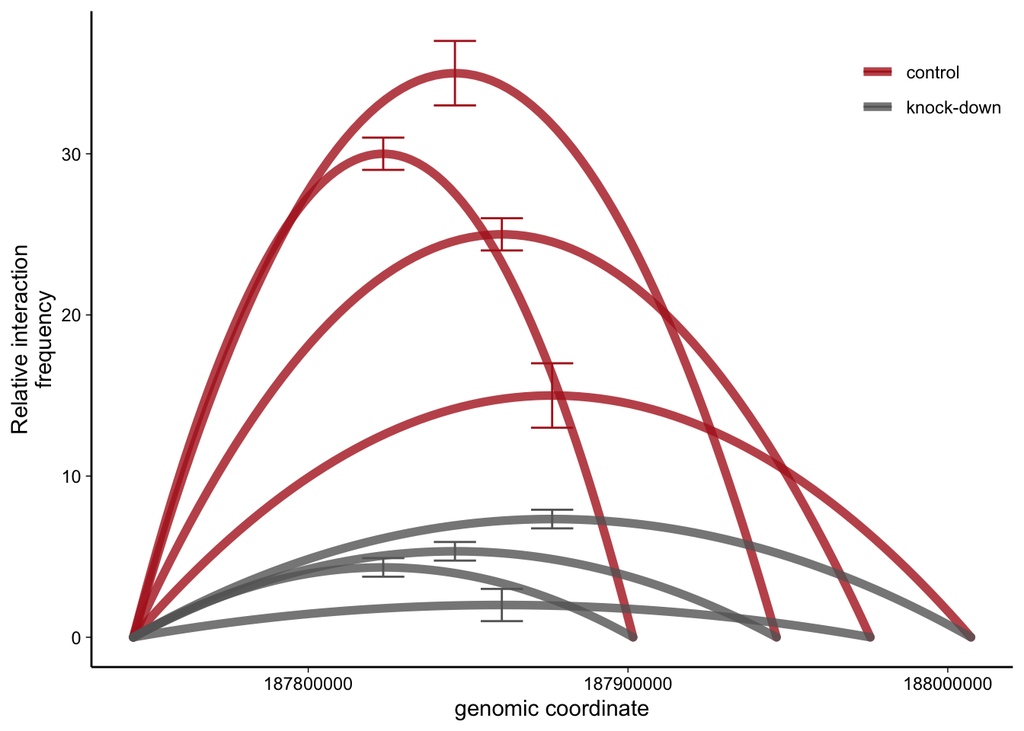

```r
p+geom_errorbar(dfsg %>% filter(point=="mid"),inherit.aes = F,size=0.5,
                mapping = aes(x=coord,ymin=mean.frequency-sd.frequency,ymax=mean.frequency+sd.frequency,color=condition))
```

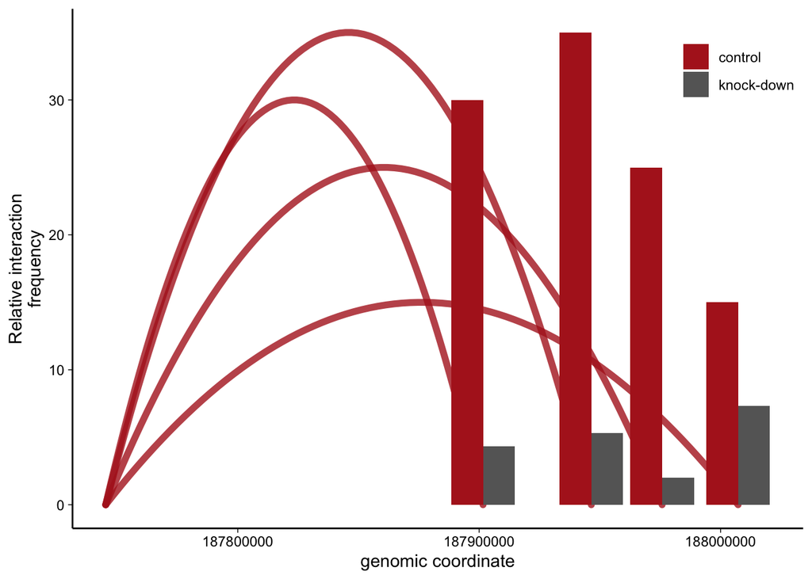

```r
ggplot()+
  geom_line(dfsg %>% filter(condition=="control"),mapping=aes(x=coord,y=mean.frequency,color=condition,group=group),
            stat="smooth",method = "lm",formula = y ~ poly(x, 2),
            se = FALSE,lineend="round",size=2,alpha=0.8)+
  geom_bar(dfs,
           mapping = aes(x=fragment.coord,y=mean.frequency,fill=condition),
           stat='identity',position=position_dodge())+
  scale_color_manual(values = c("firebrick","grey40"))+ # pick colors manually
  scale_fill_manual(values = c("firebrick","grey40"))+ # pick colors manually
  labs(y="Relative interaction\nfrequency",x="genomic coordinate",fill="")+ # rename axis labels
  theme_linedraw_noframe+ # these are the theme settings defined above
  guides(color=F)
```